# Monocle2 Analysis of Cell Differentiation and Development

Muyi Liu

7/2/2017

## Cell Type Classification

In this section, we randomly select a subpopulation of cells.

### Figure 1: Vlnplot, the number of genes, UMIs, and the percentage of mitochondrial genes

While the CreateSeuratObject imposes a basic minimum gene-cutoff, you may want to filter out cells at this stage based on technical or biological parameters. Seurat allows you to easily explore QC metrics and filter cells based on any user-defined criteria. In the example below, we visualize gene and molecule counts, plot their relationship, and exclude cells with a clear outlier number of genes detected as potential multiplets. Of course this is not a guaranteed method to exclude cell doublets, but we include this as an example of filtering user-defined outlier cells. We also filter cells based on the percentage of mitochondrial genes present.

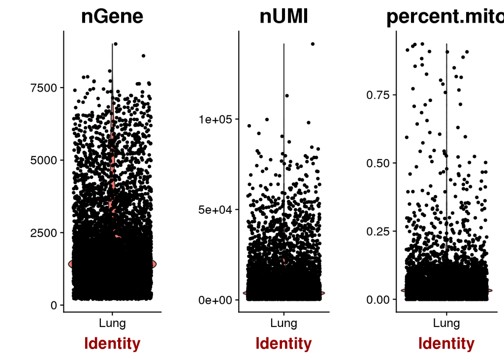

### Figure 2: GenePlot, the number UMIs VS the percentage of mitochondrial genes

GenePlot is typically used to visualize gene-gene relationships, but can be used for anything calculated by the object, i.e. columns in meta.data, PC scores etc. Since there is a rare subset of cells with an outlier level of high mitochondrial percentage and also low UMI content, we filter these cells

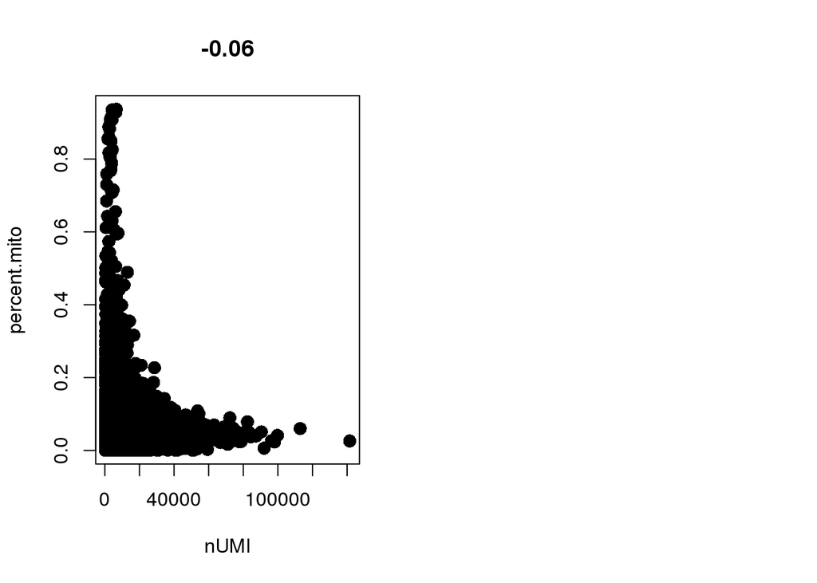

### Figure 3: GenePlot, the number UMIs VS the number of Gene

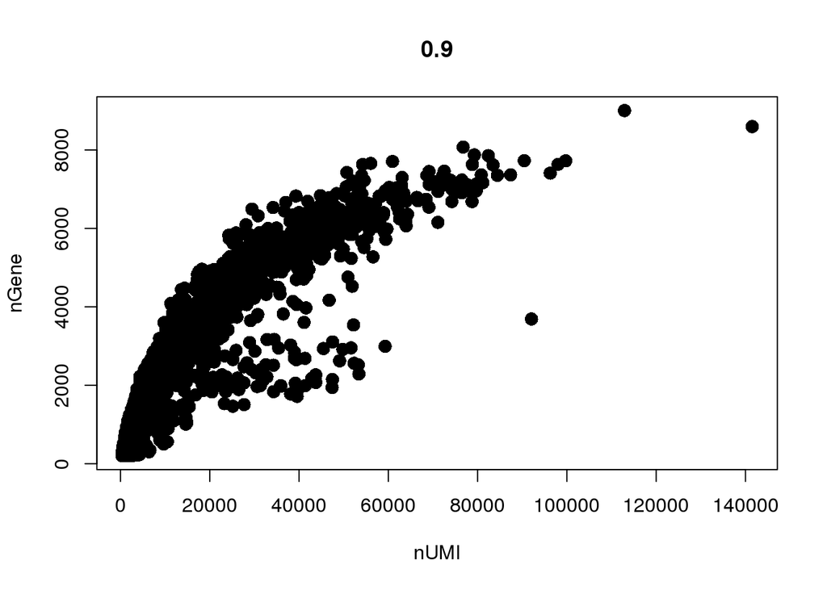

### Monocle 2 analysis:

Single cell gene expression studies enables one to profile transcriptional regulation in complex biological processes and highly hetergeneous cell populations. These studies facilitate the discovery of genes that identify certain subtypes of cells, or that mark intermediate states during a biological process as well as bifurcate between two alternative cellular fates. In many single cell studies, individual cells are executing through a gene expression program in an unsynchronized manner. In effect, each cell is a snapshot of the transcriptional program under study. The package Monocle provides tools for analyzing single-cell expression experiments. Monocle introduced the strategy of ordering single cells in pseudotime, placing them along a trajectory corresponding to a biological process such as cell differentiation by taking advantage of individual cell’s asynchronous progression of those processes. Monocle orders cells by learning an explicit principal graph from the single cell genomics data with advanced machine learning techniques (Reversed Graph Embedding), which robustly and accurately resolves complicated biological processes.

### Figure 6: Histogram: number of expressed genes in cells VS standard deviations

Only a few cells have an abnormal number of expressed genes, such as the ones that are 2 standard deviations away from the mean.

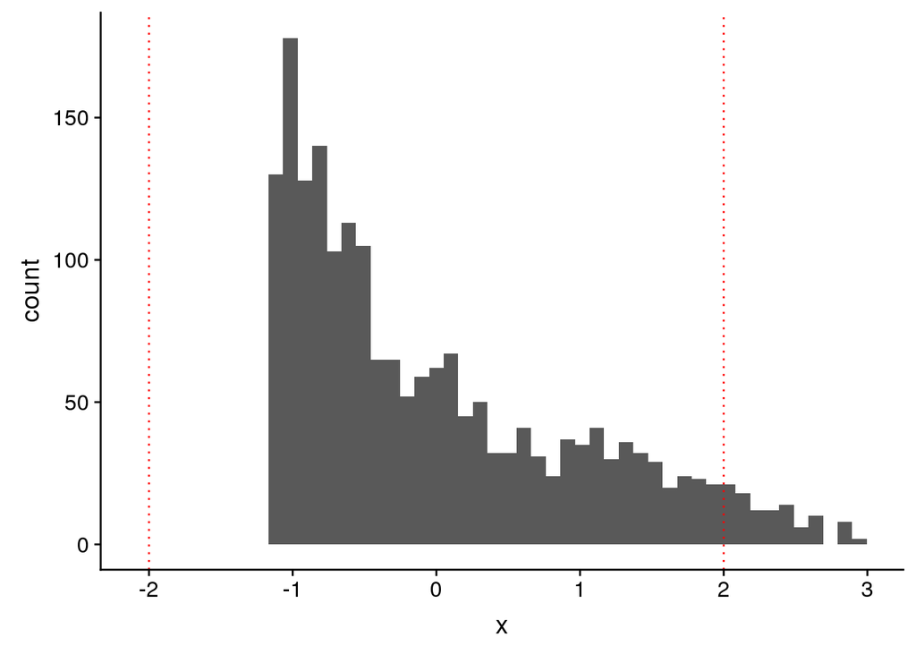

### Figure 7: Gene expression VS UMI count

We could remove the cells with much higher gene (and UMI) counts as they might be doublets but I’ll include them in this analysis.

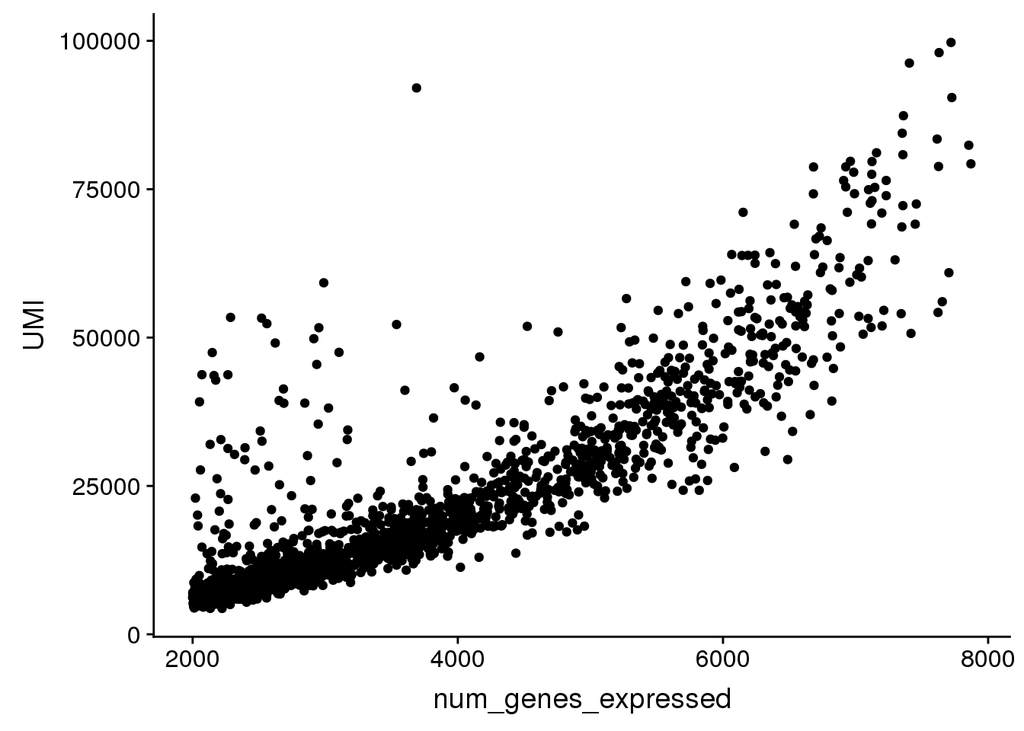

### Figure 8: Choosing ordering genes by empirical dispersion

Monocle 2 provides several alternative approaches for clustering cells and the recommended approach is to use marker genes. However, since I don’t know of any specific markers for this dataset I will use the unsupervised approach. The first step is determining a subset of genes to use for clustering; this is because not all genes are informative, such as those that are lowly expressed. The approach is to select gene based on their average expression and variability across cells. The dispersionTable() function calculates the mean and dispersion values.

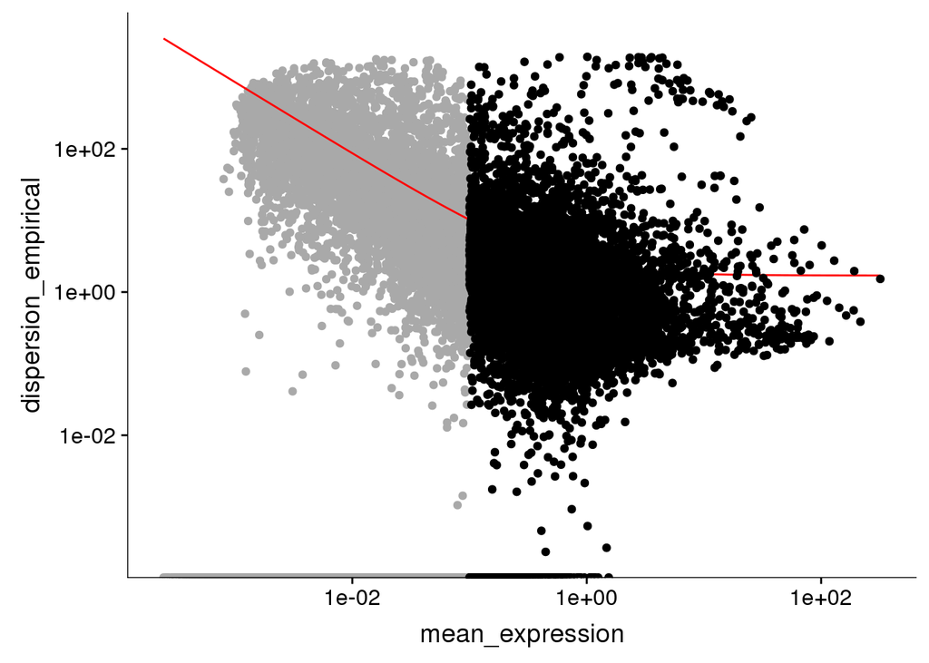

### Figure 9: Percentage of variance explained by each PC component

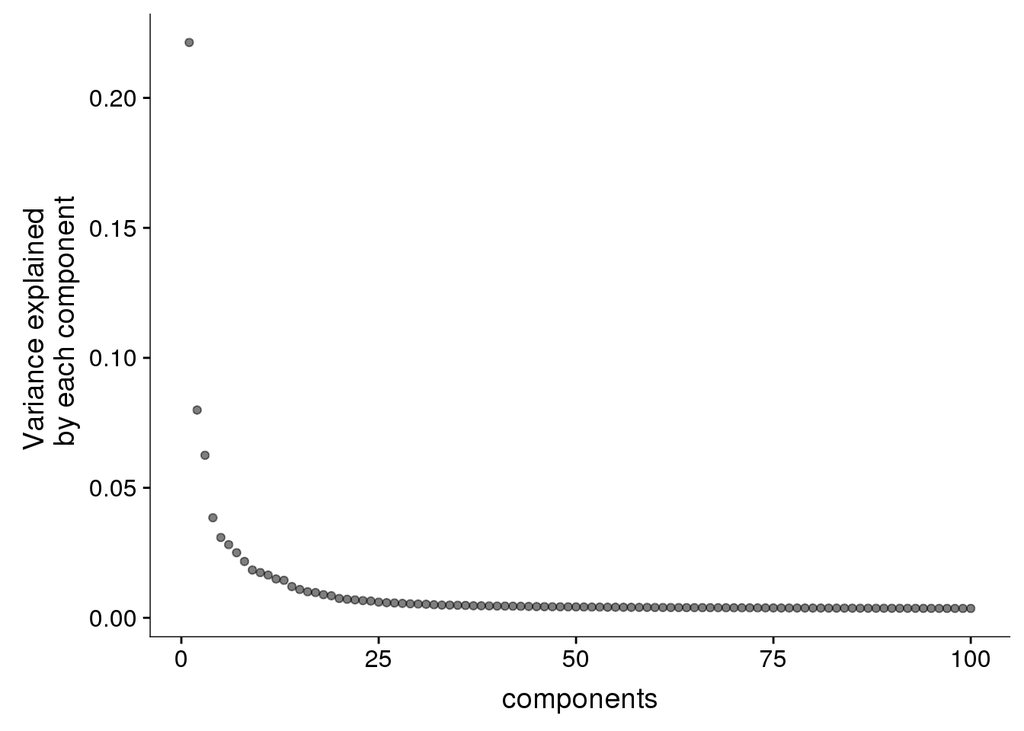

### Figure 10: TSNE plot over clusters

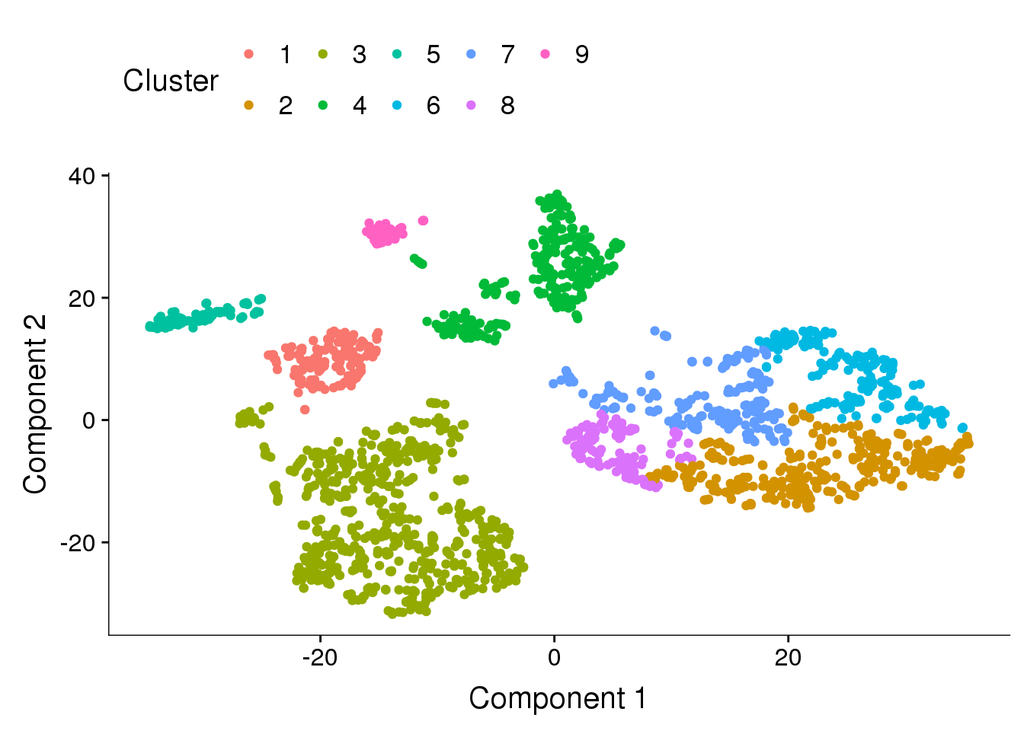

### Table 1: The collected marker genes in each cluster

The predicted marker genes in Lung

| pval | gene_short_name | Cluster |
| --- | --- | --- |
| 0 | MS4A1 | 1 |
| 0 | CD19 | 1 |
| 0 | BANK1 | 1 |
| 0 | FCRL4 | 1 |
| 0 | TNFRSF13B | 1 |
| 0 | TPSAB1 | 1 |
| 0 | SPP1 | 1 |
| 0 | PTPRCAP | 1 |
| 0 | CD79B | 1 |
| 0 | CPA3 | 1 |
| 0 | GSTP1 | 1 |
| 0 | BCAS4 | 1 |
| 0 | AGR2 | 1 |
| 0 | GLUL | 1 |
| 0 | AIM2 | 1 |
| 0 | IGLV3-25 | 1 |
| 0 | IER3 | 1 |
| 0 | FCMR | 1 |
| 0 | TIMP1 | 1 |
| 0 | C19orf33 | 1 |
| 0 | IGKV1-5 | 2 |
| 0 | IGLV2-14 | 2 |
| 0 | SPINK6 | 2 |
| 0 | IGLV1-40 | 2 |
| 0 | JCHAIN | 2 |
| 0 | TPSAB1 | 2 |
| 0 | IGKV4-1 | 2 |
| 0 | LGALS7B | 2 |
| 0 | LGALS7B | 2 |
| 0 | IGLV2-23 | 2 |

[output cut: 70 more lines]

### Figure 11: Predicted Marker genes in Lung clusters

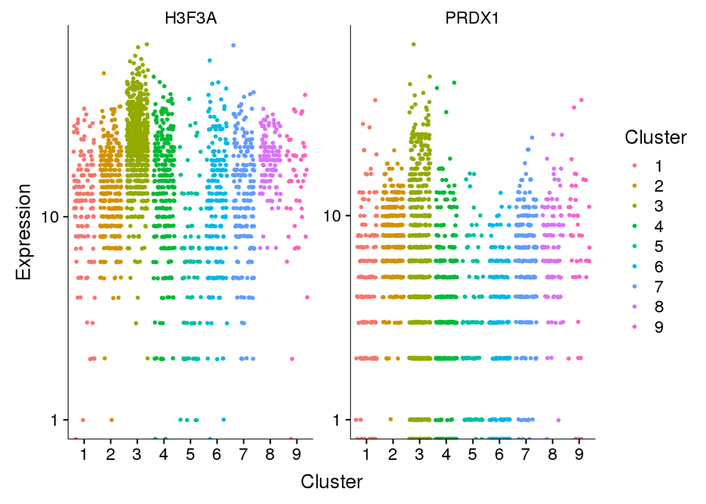

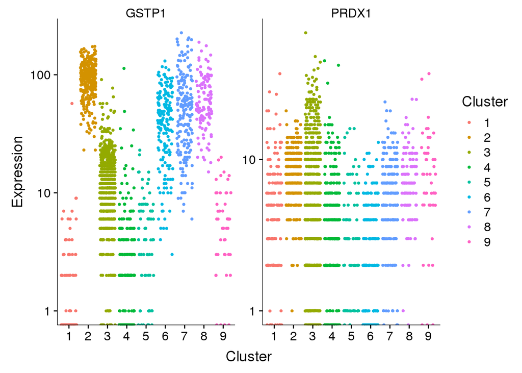

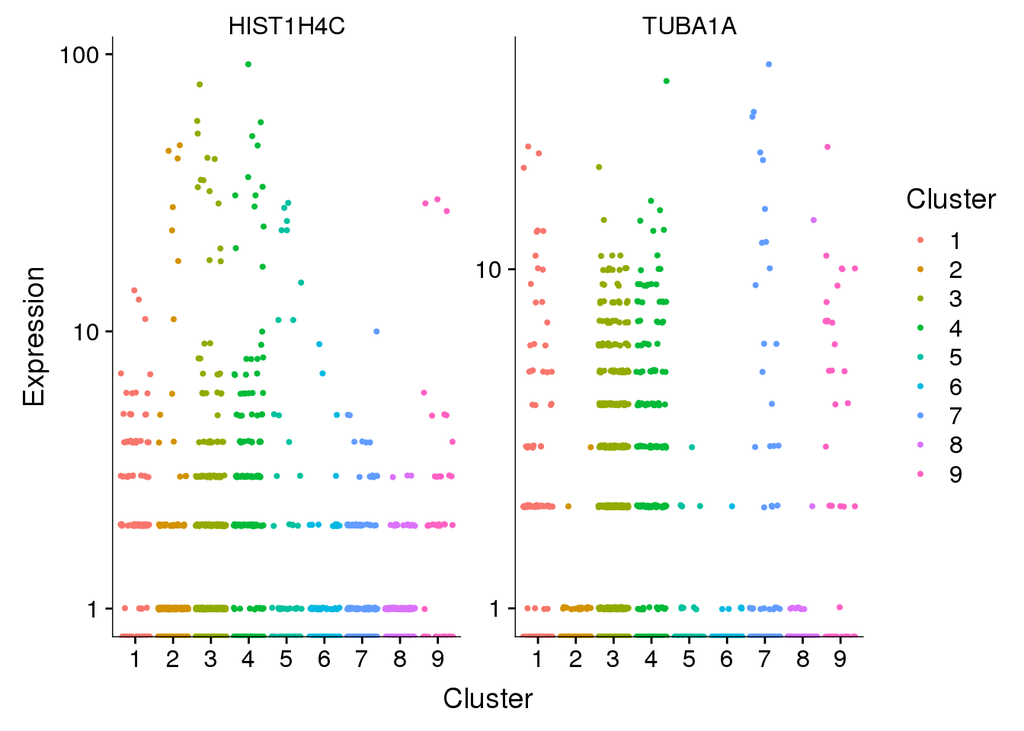

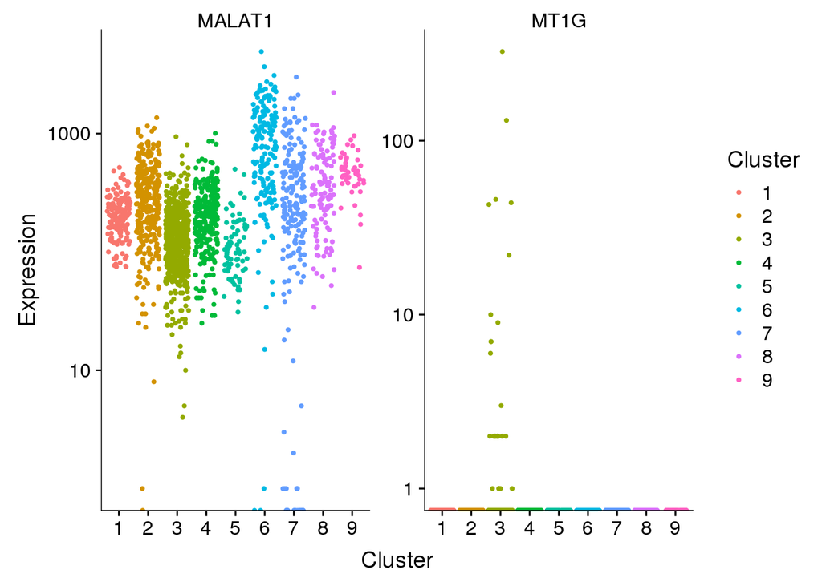

### Table 2: The predict cell cluster in Lung

The cell cluster index in Lung

| x |  |
| --- | --- |
| AAACCTGCACCAGGTC | 4 |
| AAACCTGCACCTCGTT | 2 |
| AAACCTGCAGCTGTGC | 4 |
| AAACCTGTCCTCAATT | 3 |
| AAACGGGCACCAGATT | 3 |
| AAACGGGGTAATCACC | 2 |
| AAACGGGTCCCAAGTA | 3 |
| AAAGATGGTCGAAAGC | 3 |
| AAAGATGGTTACCGAT | 3 |
| AAAGATGGTTGGTAAA | 6 |
| AAAGATGTCCGAATGT | 6 |
| AAAGCAAAGAATTGTG | 4 |
| AAAGCAACAAGGTTCT | 2 |
| AAAGCAAGTAGCTGCC | 2 |
| AAAGCAATCGTACGGC | 2 |
| AAAGCAATCTCAAGTG | 7 |
| AAAGTAGCAATGTAAG | 4 |
| AAAGTAGGTAATTGGA | 2 |
| AAAGTAGGTCGCGAAA | 5 |
| AAATGCCCAATGTAAG | 1 |
| AAATGCCCAGCTCGAC | 3 |
| AAATGCCTCCAAACAC | 3 |
| AACACGTCACGACTCG | 4 |
| AACACGTTCCAGAGGA | 9 |
| AACACGTTCTTGCATT | 3 |
| AACCATGCATGTTGAC | 3 |
| AACCATGCATTCTCAT | 3 |
| AACCATGGTGTTGAGG | 3 |
| AACCATGGTTGATTCG | 4 |
| AACCATGTCAATCTCT | 8 |

[output cut: 1923 more lines]

Single cell trajectory analysis Monocle 2 introduced the strategy of using RNA-Seq for single cell trajectory analysis. Rather than purifying cells into discrete states experimentally, Monocle uses an algorithm to learn the sequence of gene expression changes each cell must go through as part of a dynamic biological process. Once it has learned the overall “trajectory” of gene expression changes, Monocle can place each cell at its proper position in the trajectory. You can then use Monocle’s differential analysis toolkit to find genes regulated over the course of the trajectory.

The ordering workflow:

Step 1: choosing genes that define progress

Step 2: reducing the dimensionality of the data

Step 3: ordering the cells in pseudotime

### Figure 12: Trajectory plot by clusters

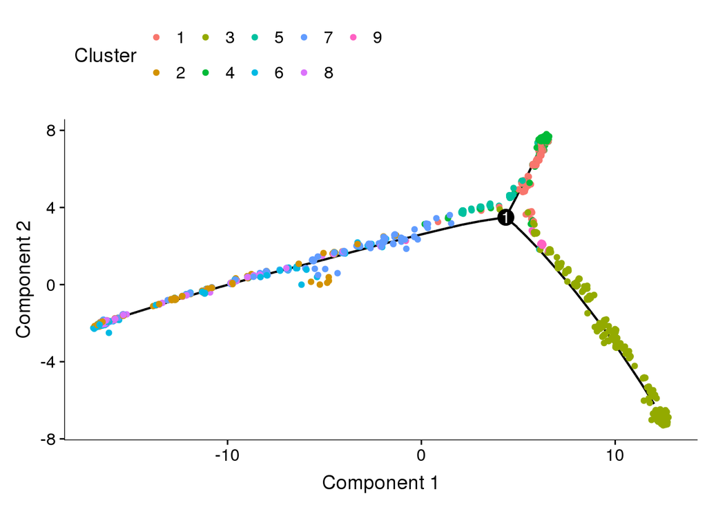

### Figure 13: Trajectory plot by Pseudotime

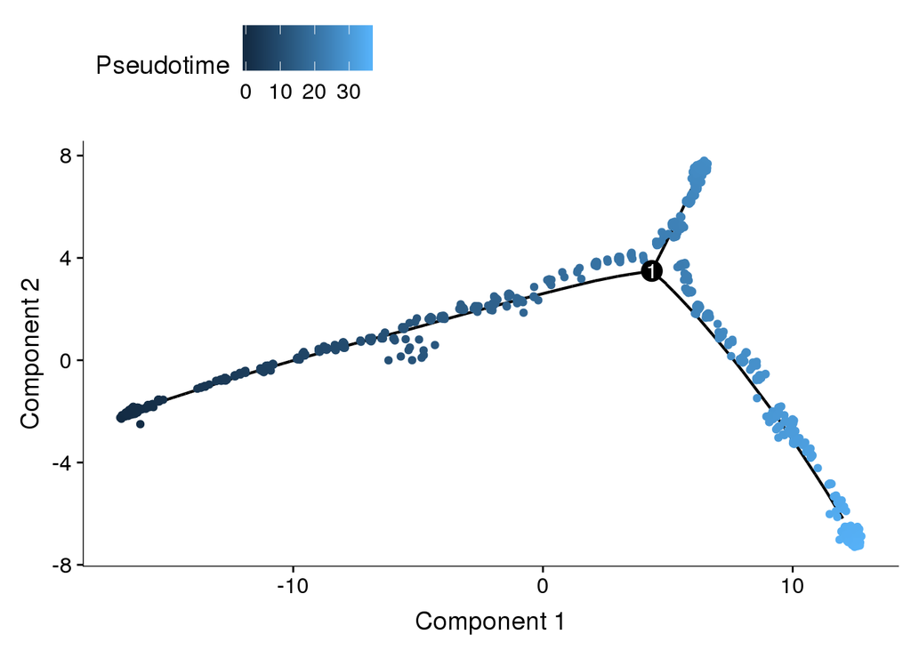

### Figure 14: Gene expression plot by ordering

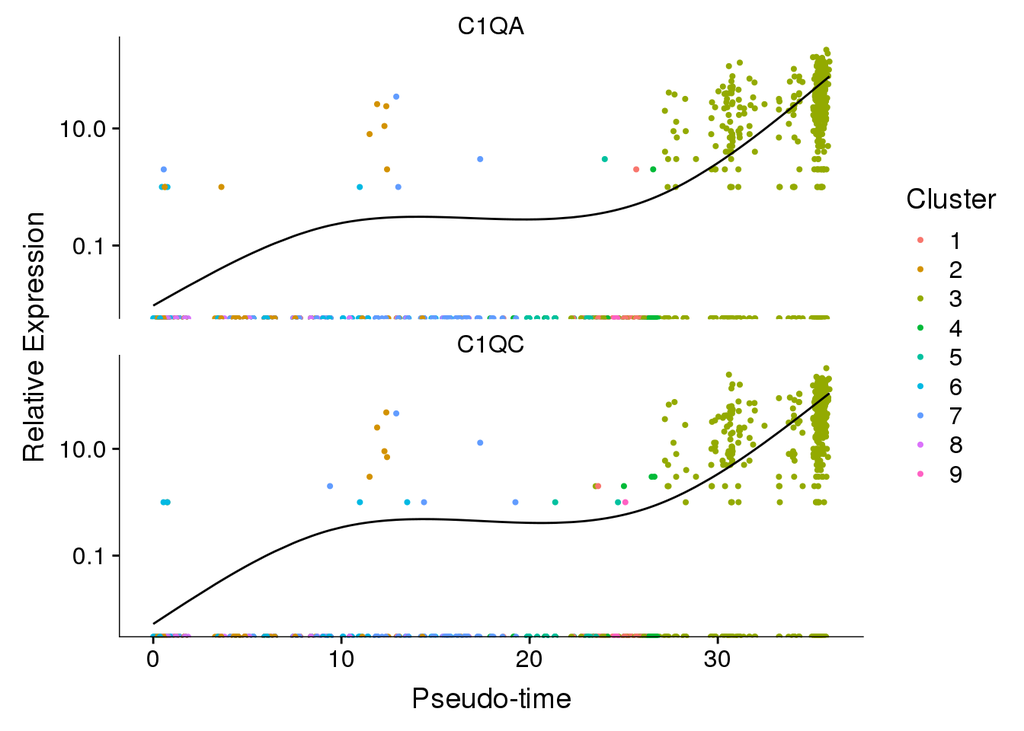

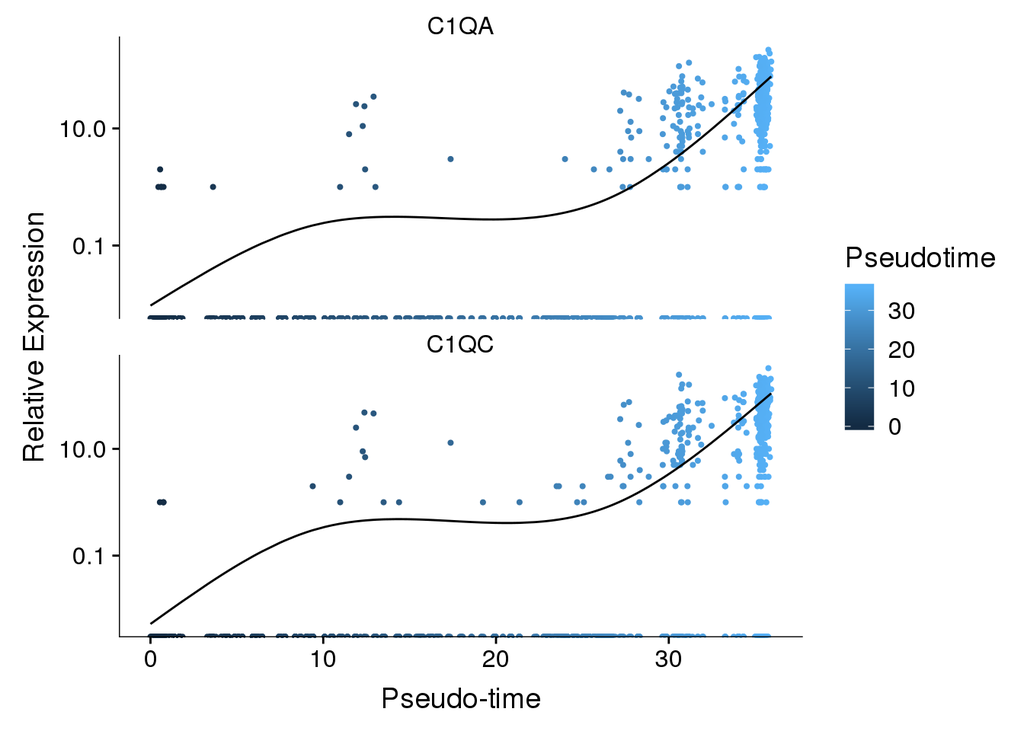

### Figure 15: Genes follow similar kinetic trends

A common question that arises when studying time-series gene expression studies is: “which genes follow similar kinetic trends”? Monocle can help you answer this question by grouping genes that have similar trends, so you can analyze these groups to see what they have in common. Monocle provides a convenient way to visualize all pseudotime-dependent genes. The function plot_pseudotime_heatmap takes a CellDataSet object (usually containing a only subset of significant genes) and generates smooth expression curves much like plot_genes_in_pseudotime. Then, it clusters these genes and plots them using the pheatmap package. This allows you to visualize modules of genes that co-vary across pseudotime.

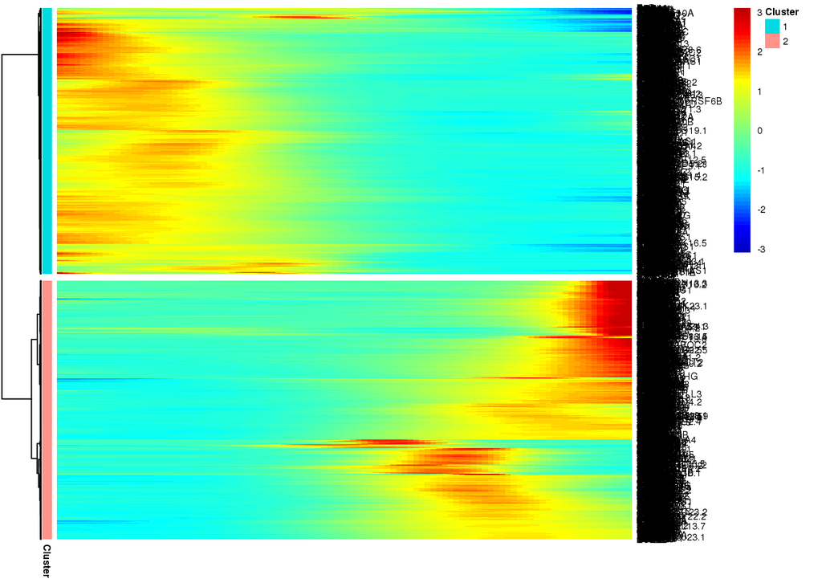

### Figure 16: Cell type distribution

This is the cell type distribution.

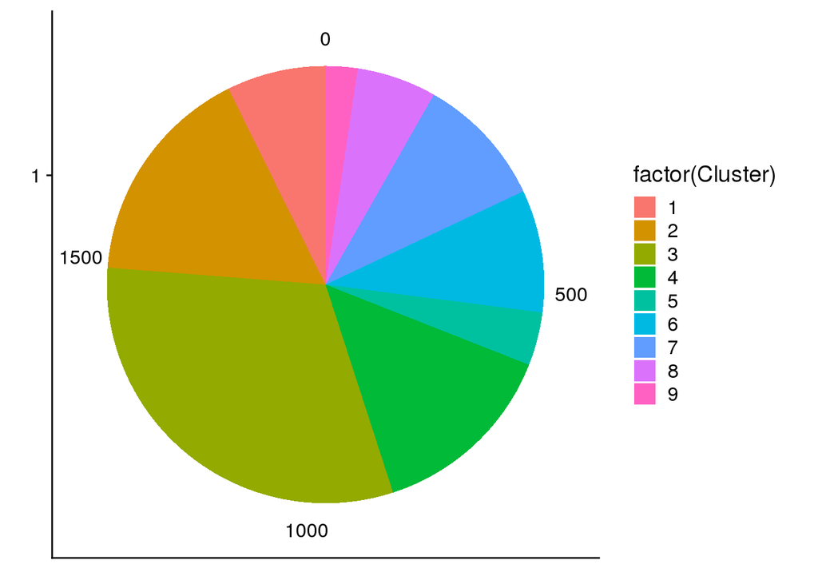